# Introduction To Raster Analysis

CPLN 503- Modeling Geographic Objects

Published

October 30, 2024

# Introduction

While this is a vector data course, raster data is the other big half of GIS data analysis. Raster data are generally used to represent *continuous* values. So, if we think about vector data ( i.e. points, lines and polygons) as representing *distinct* units we can better understand what rasters represent. Land use/land cover, temperature, slop/elevation…all of these are values that lend themselves well to rasters because they can represent the continuous, gradual nature of these features. You absolute can represent these values using vectors, but rasters give us a bit more flexibility. Due to the nature of rasters we can combine these disparate layers in creative ways as we play around with combinations of continuous layers.

## Map Algebra and Raster Cubes

So, the basic structure of raster data sets are we have a regular grid, usually the pixels of an image (like a satellite, but it can be another set of a regular grid) and each pixel represents a single *value*. So, for vector data we have an attribute table so any given geometry can represent any number of variables, but for rasters any particular pixel represents only a single value. So, if we want to do some kind of multivariate operation we need to have *multiple* rasters (Figure 1).

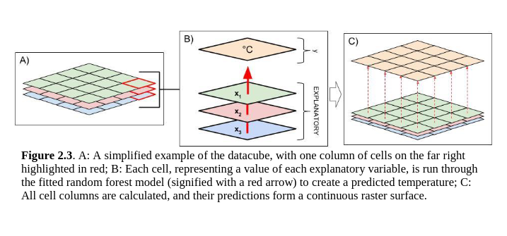

Figure 1- Source: [Jackson Lee Voelkel. 2018. “Urban Geocomputation: Two Studies on Urban Form and its Role in Altering Climate”](https://pdxscholar.library.pdx.edu/cgi/viewcontent.cgi?article=5369&context=open_access_etds)

Because each cell represents a singular value you can actually perform algebraic operations on your layers to create new layers! This kind of operation is referred to as [map algebra](https://gisgeography.com/map-algebra-global-zonal-focal-local/). Review the linked guide.

With this basic exposure let’s jump into the examples Prof. O’Neill covers.

# Using Rasters in R

The modern raster package in R is the [**terra**](https://rspatial.org/) package. There is a legacy [**raster**](https://cran.r-project.org/web/packages/raster/index.html) package that is still usable, but is in the process of being deprecated and replaced by **terra**. So, the examples here will make use of **terra**.

So…let’s get started.

## Reading In Our Data

Okay, we’ll be using our standard **pacman** set up and we will be bringing in the **tidyverse**, **sf** and **terra**. First we will just bring in our vector county boundary. This should feel familiar by now. Check the attributes for the county and we’ll move on from there.

```r
if(!require(pacman)){install.packages("pacman"); library(pacman)}
p_load(tidyverse, sf, terra, tmap)

county <- st_read("Raster_Intro/County_Boundaries.shp", quiet = TRUE)
```

Next we will bring in the land cover and elevation raster layers. We will make use of the `rast()` function from **terra** to do this. Again, by now, this should feel familiar to us. It is no different than using `st_read()`, `read_csv()` or any other of the many read functions in R.

```r
lulc <- rast(x = "Raster_Intro/landcover/")

elevation <- rast(x = "Raster_Intro/elevation/")
```

Now, we should notice something different here. The `rast()` function does not target a specific file, but a *folder*. So, while rasters are images, they’re still images with associated geographic reference information, metadata etc…so we call to the folder associated with all these files. If we look at our local environment we should see three objects. Our county simple features dataframe should look very familiar by now and we have some “SpatRaster” class objects. If you type the object name into your console it should give you some basic information on the layer: we should see class, the dimensions of our raster, the projection, extent and a few other features.

```r
elevation
```

```
class       : SpatRaster
dimensions  : 2170, 2371, 1  (nrow, ncol, nlyr)
resolution  : 100, 100  (x, y)
extent      : 2256096, 2493196, 144928.2, 361928.2  (xmin, xmax, ymin, ymax)
coord. ref. : NAD83 / Pennsylvania South
source      : elevation
name        :
min value   :  -85.37336
max value   : 1174.59937
```

We can also use the base-R plot function to get a basic plot of our rasters.

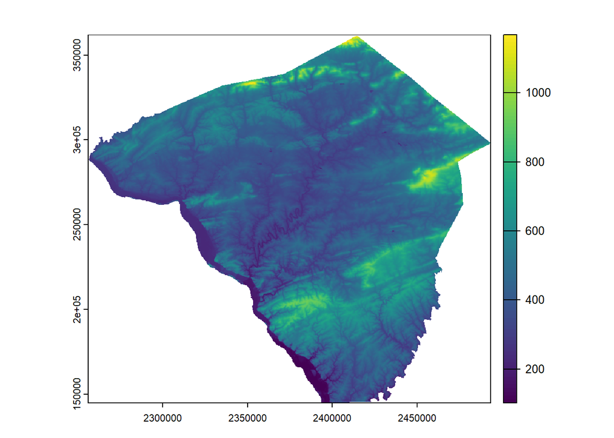

Elevation Raster

Now, elevation is a continuous value, but we have a land cover raster that is *categorical*. We can map these categories using **tmap**, but first let’s take a look at what makes up our categorical raster

```r
lulc
```

```
class       : SpatRaster
dimensions  : 2170, 2371, 1  (nrow, ncol, nlyr)
resolution  : 100, 100  (x, y)
extent      : 2256096, 2493196, 144928.2, 361928.2  (xmin, xmax, ymin, ymax)
coord. ref. : NAD83 / Pennsylvania South
source      : landcover
name        :
min value   : 1
max value   : 5
```

```
stars object downsampled to 1045 by 957 cells. See tm_shape manual (argument raster.downsample)
```

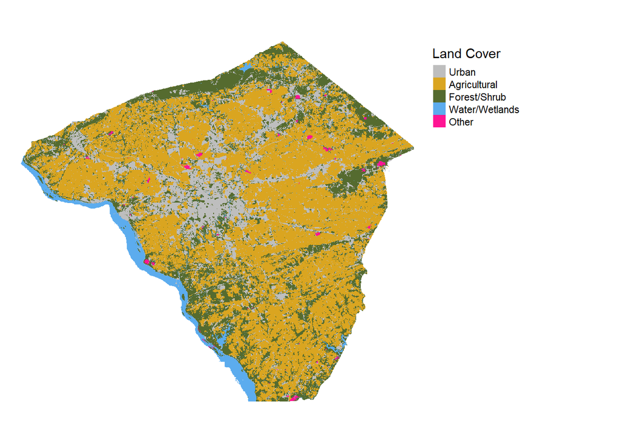

Land Use/Land Cover

## Working Raster Calculations

Prof. O’Neill introduces us to the “Spatial Analyst” toolbox in ArcPro, the premier set of tools for raster analysis in Pro. Let’s play with some map algebra.

### Pulling out elevations

First, we’ll work with our elevation raster and create a new raster with elevation values greater than or equal to 600ft. What do we think our output will be?

```r
elev_600 <- elevation >= 600
```

Okay…let’s break this down. So, first all, notice that we can apply our expression directly to our elevation raster. We don’t need a `filter()` equivalent like in **dplyr** nor do we need to make use of any bracket type notation we use in working with dataframes. This speaks to the rather unique nature of rasters as a data type. They are more akin to matrices than they are to two-dimensional dataframes we work with. So, let’s take a look at what this output is.

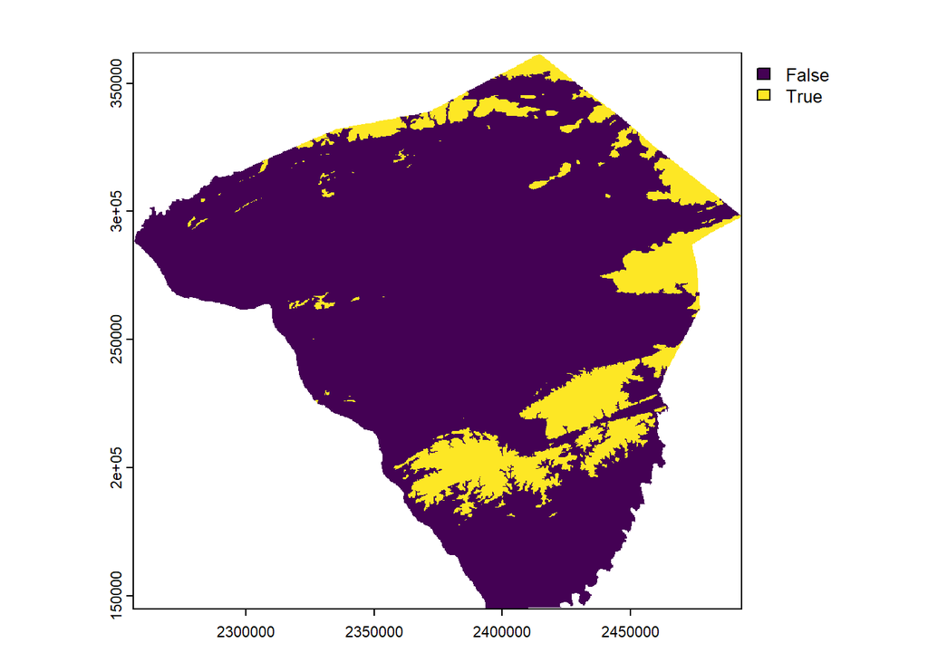

We end up with a raster that displays TRUE/FALSE cells? What’s going on? We get a boolean output that tells us whether or not a cell meets a certain criteria. This is a pretty cool outcome that is distinct from how we have worked with vector data, but it opens up entirely new paths of analysis.

### Working with categorical rasters

Next, let’s run a similar operation on our landcover dataframe. In this case, we are looking for cells that are equal to forest landcover, or 3 in terms of the values in our raster layer. What do we think our output should look like?

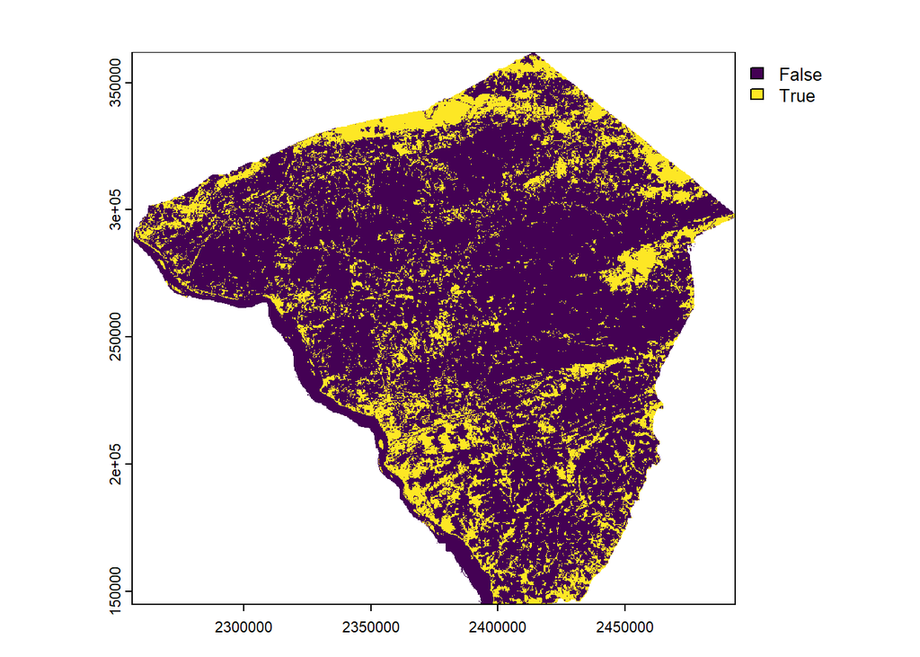

```r
forests <- lulc == 3

plot(forests)
```

Just like before we get a binary raster layer telling us where cells were equal to the forest layer (in this case, 3) and where they were not.

Thus far, this should feel pretty straightforward. If not, take a step back and review what we’ve done thus far. We’ve read in our data and we have created two new layers that resulted in new binary rasters letting us know which cells meet the conditions we laid out (>= 600 ft for elevation and forest/value 3 for land use).

So, what can we do with this? Well, let’s see what happens if we *add* our two new layers together. What do we think our output will be?

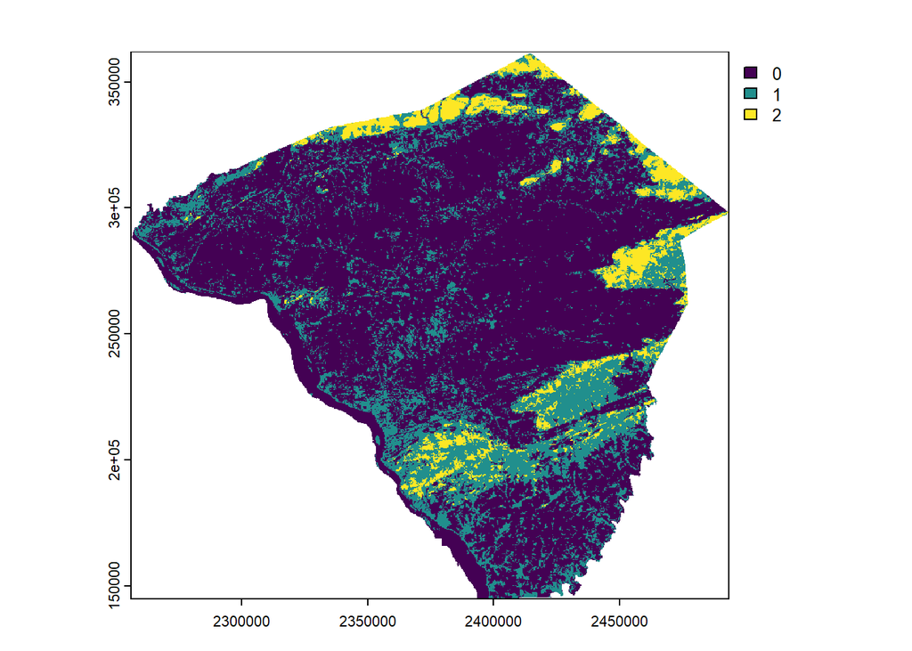

```r
forests_600 <- elev_600 + forests

plot(forests_600)
```

I hope you can start to see the potential in working with rasters in this way. While we do not do so in this class, this basic workflow underpins many site suitability type analyses that take a series of different rasters and combine them in multiple ways to figure out the best location for any number of things like facility locations, probable species locations for plants or animals or flood/fire risks.

Also, as an addendum, we can apply multiple conditional statements to our rasters if we want. In this case, we want to know what cells are particularly high ( > 1000 ft) or particularly low (< 300 ft).

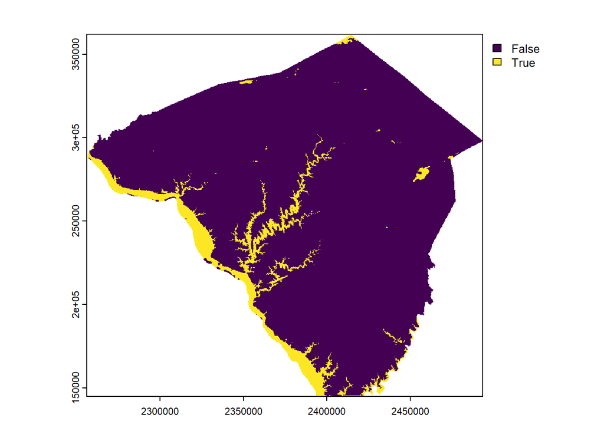

```r
elev_300_1000 <- elevation > 1000 | elevation < 300

plot(elev_300_1000)
```

This shows us the flexiblity of map algebra here with respect to logical conditions.

### Working Distances and Extents

Okay, next, following Prof. O’Neill’s video we will go over how we can work with distance in a raster format and how to work with our extents. First, let’s load in our new layer of the Euclidean Example points. In order to do so we will use the `vect()` function from **terra**. This the vector-based data import function specific to the **terra** package.

```r
euclid_points <- vect("2023-10-25_Raster_Intro_Data/Euclidean_Example.shp")
```

What do we see? The `euclid_points` layer is of a SpatVector class, and what info is shown to you if you type `euclid_points` into your console?

Okay, now,before we calculate our distances we need to convert our `euclid_points` into a raster (if we kept it as a vector we would get a distance matrix returned to us, not what we’re looking for here). So, we will convert our layer to a raster and then run our distance.

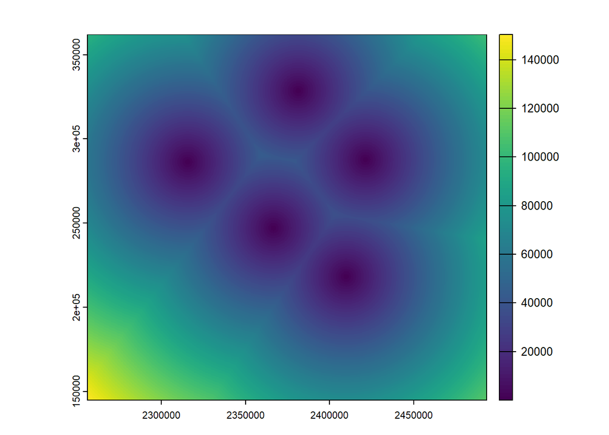

```r
euclid_points_rast <- rasterize(euclid_points, y = elevation)

euclid_dist <- distance(euclid_points_rast)

plot(euclid_dist)
```

So, what did we do? We used the `rasterize()` function to convert our vector based points file into a raster that shares the same *extent* and cell *resolution size* as the elevation raster, and then we fed it into the `distance()` function. Ideally, whenever you’re working with rasters you want to be working with the same extent and resolution size so everything lines up.

So, what does this plot show us? It shows us the distance from the *nearest* point on a continuous surface. In this case, the lighter the color the further the cell is from a point. Now, note that this behavior is different than the default distance function behavior Prof. O’Neill shows in his video doing this operation in ArcPro. But, as he notes, you can set the extent for your final raster, just like we did here, in ArcPro, and you should end up with an equivalent layer.

# Good job

Okay, that’s a very brief intro to some raster operations in R! If this kind of thing interests you, then, first, do the bigger lab for today. And, after that, think about Modeling Geographic Space. It is the raster equivalent of this course.